# Discovering the times where stations do not have bikes

## by Walid Alashry

## Investigation Overview

> In this invistigation, I want to know what are the stations that does not have bikes at certain times of day. The main focus is the stations and the time.

## Dataset Overview

> This data consists of 183412 bike trips in Feb-2019. it provides information about start and end time of each trip, duration, start and end station for each trip, start and end station id for each trip, start and end station latitude and longitude, bike_id, user's birthday and gender, customer type and bike share information.

## (Visualization 1)

> The distibution of trips in workdays are bimodal(at the going to and returning from work hours) while the distribution of trips in weekend are nearly normal.

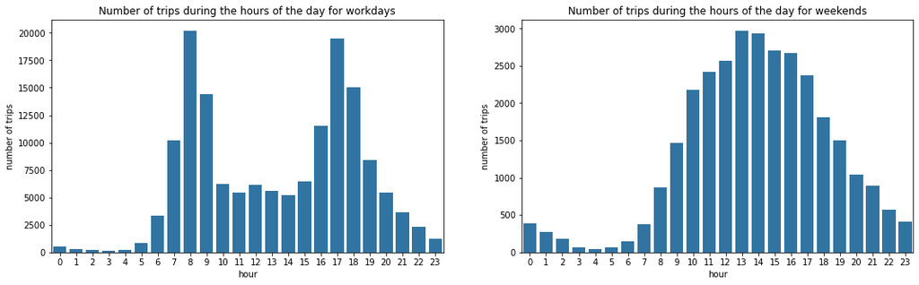

## (Visualization 2)

> The number of trips in workdays are relatively close to each other ,then the number of trips decreased dramatically by around 50% at weekends.

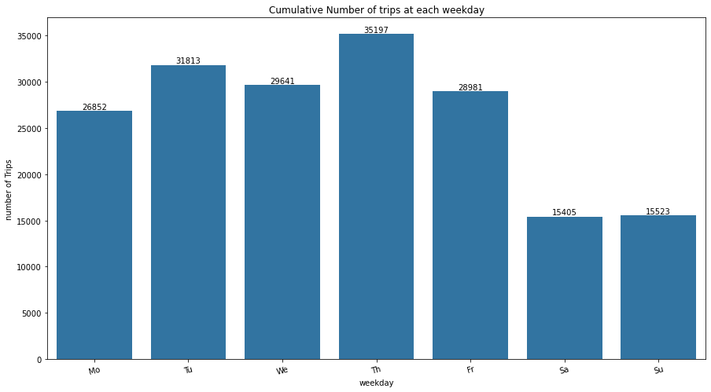

## (Visualization 3)

> Most of our trips are 30 minutes or less with average of 12 minutes. There are some trips with very high duration time.

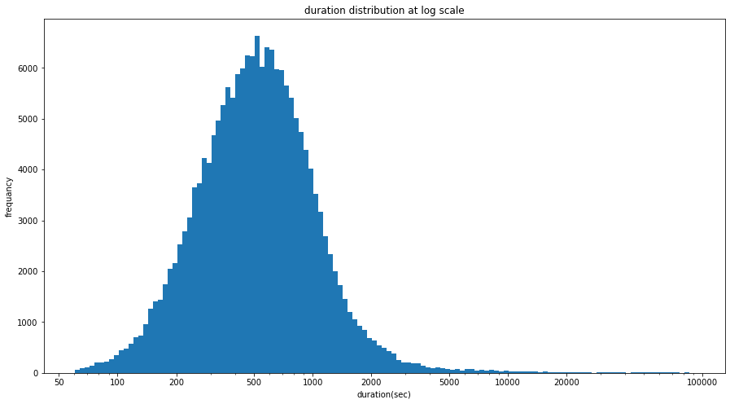

## (Visualization 4)

> There are 15097 trips that starts from station that is not the same station that the same bike ended at which means the company tranfer them or people using bikes without starting a trip.

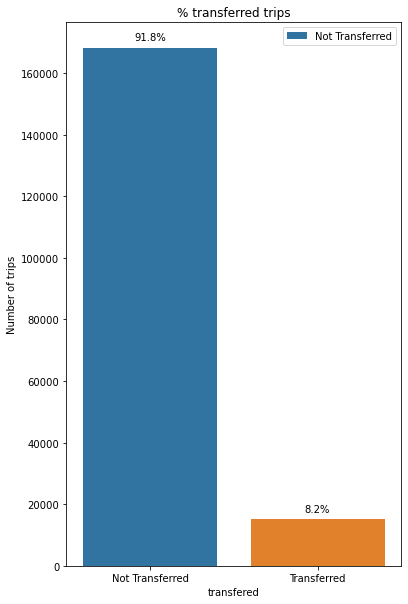

```python
df_ordered['transfered'].value_counts()
```

```
Not Transferred    168118
Transferred         15097
Name: transfered, dtype: int64
```

## (Visualization 5)

> The number of bikes by end of each day in our top three stations.

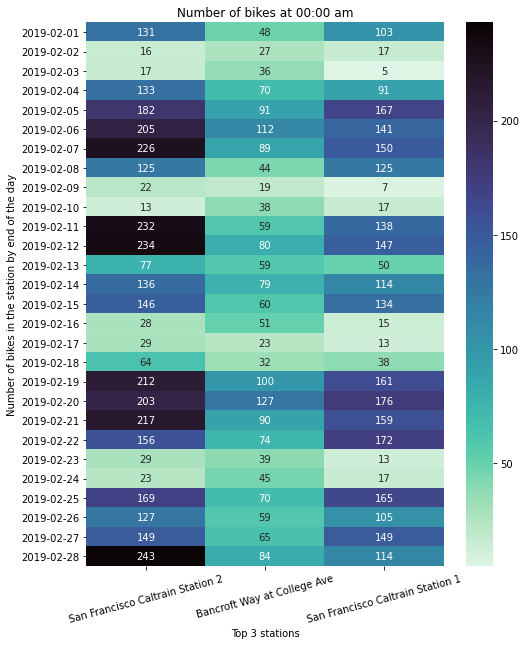